# R Notebook

# PHS Scottish Stroke Statistics

This notebook contains steps to create a predictive multivariate model to predict future stroke incidence rates using future population predictions per year as published by NRS (National Records Scotland)

```r
library(tidyverse)
library(GGally)
library(janitor)
library(modelr)
library(broom)
library(ggfortify)

activity_hb <- read_csv("../clean_data/stroke_activity_healthboard.csv")
```

## Joining

Next step: join the population estimates to the activity_hb dataset.

```r
pop_est <- read_csv("../clean_data/pop_est_nhs_format.csv")
```

```r
# in activity_hb change financial year into regular year
# since its mid-year population estimates, this does not matter for the join

activity_hb_reduced <- activity_hb %>%
  mutate(year = as.numeric(str_sub(financial_year, start = 1, end = 4), .before = financial_year)) %>%
  select(year, hbr, admission_type, age_group, sex, diagnosis, number_of_discharges, crude_rate, easr)
```

```r
# Healthboard numbers in population estimate dataset are mixed of old and new numbers
# recode so all are new codes

pop_est_hb <- pop_est %>%
  mutate(hbr = recode(hbr,
                     "S08000001" = "S08000015",
                     "S08000002" = "S08000016",
                     "S08000003" = "S08000017",
                     "S08000004" = "S08000029",
                     "S08000005" = "S08000019",
                     "S08000006" = "S08000020",
                     "S08000007" = "S08000031",
                     "S08000008" = "S08000022",
                     "S08000009" = "S08000032",
                     "S08000010" = "S08000024",
                     "S08000011" = "S08000025",
                     "S08000012" = "S08000026",
                     "S08000013" = "S08000030",
                     "S08000014" = "S08000028"))
```

Join!

```r
# join
activity_popest_hb <- activity_hb_reduced %>%
  left_join(pop_est_hb, by = c("hbr" = "hbr", "sex" = "sex", "year" = "year", "age_group" = "age_group")) %>%
  select(!"...1")

activity_popest_hb
```

| year | hbr | admission_type | age_group | sex | diagnosis | number_of_discharges | crude_rate | easr | area_name | population_size |
| --- | --- | --- | --- | --- | --- | --- | --- | --- | --- | --- |
| 2012 | S08000015 | All | 0-44 years | Males | Cerebrovascular Disease | 44 | 46.7990513 | 52.2647510 | Ayrshire and Arran | 94019 |
| 2012 | S08000015 | All | 0-44 years | Females | Cerebrovascular Disease | 24 | 24.8532107 | 23.0884831 | Ayrshire and Arran | 96567 |
| 2012 | S08000015 | All | 45-64 years | Males | Cerebrovascular Disease | 212 | 408.4070200 | 406.3155590 | Ayrshire and Arran | 51909 |
| 2012 | S08000015 | All | 45-64 years | Females | Cerebrovascular Disease | 153 | 272.5232446 | 274.0774683 | Ayrshire and Arran | 56142 |
| 2012 | S08000015 | All | 65-74 years | Males | Cerebrovascular Disease | 251 | 1271.7231595 | 1309.3818326 | Ayrshire and Arran | 19737 |
| 2012 | S08000015 | All | 65-74 years | Females | Cerebrovascular Disease | 213 | 967.8738583 | 977.9670190 | Ayrshire and Arran | 22007 |
| 2012 | S08000015 | All | 75plus years | Males | Cerebrovascular Disease | 340 | 2613.5752172 | 2808.0148645 | Ayrshire and Arran | 13009 |
| 2012 | S08000015 | All | 75plus years | Females | Cerebrovascular Disease | 502 | 2531.5179022 | 2490.1136706 | Ayrshire and Arran | 19830 |
| 2012 | S08000016 | All | 0-44 years | Males | Cerebrovascular Disease | 11 | 41.0800314 | 47.4955757 | Borders | 26777 |
| 2012 | S08000016 | All | 0-44 years | Females | Cerebrovascular Disease | 11 | 40.3506841 | 36.0866821 | Borders | 27261 |

[output cut: 990 more lines]

```r
# save the join to clean_data
write.csv(activity_popest_hb, file = "../clean_data/activity_popest_hb.csv")

#write.csv(population_estimates_nhs_format, file = "clean_data/pop_est_nhs_format.csv")
```

## further data wrangling

```r
#check for NAs, and drop the missing number of discharges missing
# (these are removed by NHS due to confidentiality reasons)
# there are also missing population_size numbers since,
# not all age_groups exist in my dataset

activity_popest_clean <- activity_popest_hb %>%
  drop_na("number_of_discharges") %>%
  drop_na("population_size")
```

Secondly, there are multiple diagnosis types and admission types that are subdivided in multiple categories. I am only interested in the total in admission_type this is categorised under “all” and for diagnosis this is categorised under Cerebrovascular disease

```r
activity_popest_clean <- activity_popest_clean %>%
  filter(admission_type == "All") %>%
  filter(diagnosis == "Cerebrovascular Disease")

activity_popest_clean %>%
  distinct(diagnosis)
```

| diagnosis |
| --- |
| Cerebrovascular Disease |

## Step 1: look at relationships between variables and Crude_rate/ number_of_discharges

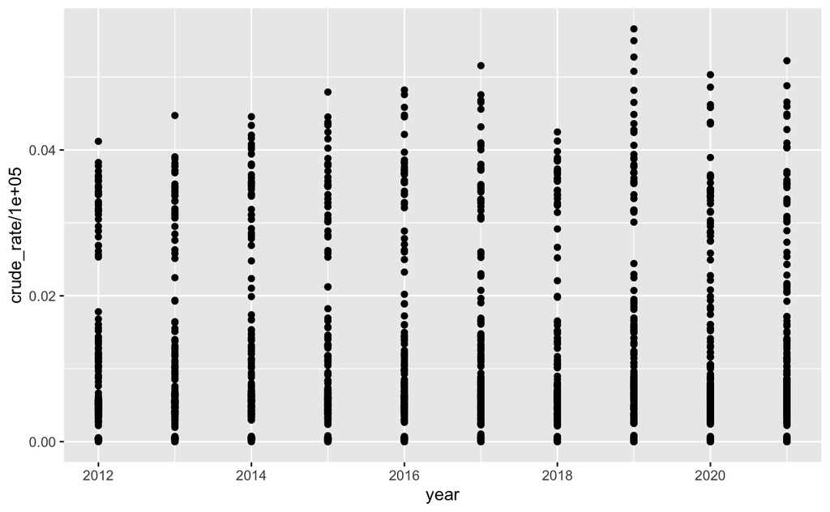

```r
# How is crude_rate distributed?

activity_popest_clean %>%
  ggplot() +
  aes(x = year, y = crude_rate/100000) +
  geom_point()
```

```r
# so it runs from 0 to almost 6%
```

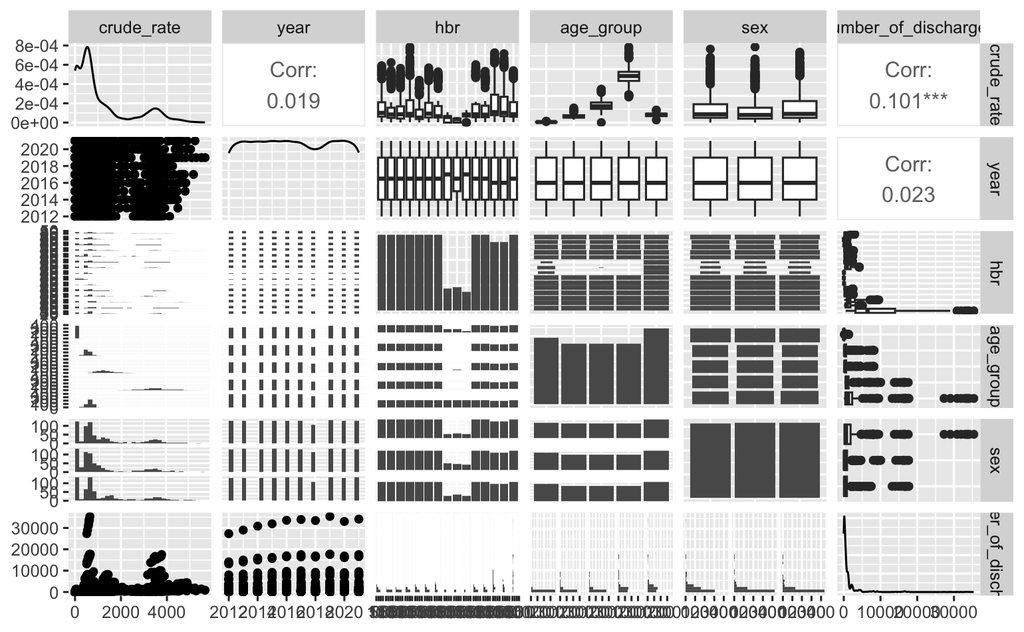

```r
# first check the relationships between variables and the crude_rate

set_1 <- activity_popest_clean %>%
  select(crude_rate, year, hbr, age_group, sex, number_of_discharges)

set_2 <- activity_popest_clean %>%
  select(crude_rate, admission_type, diagnosis, easr, population_size)

ggpairs(set_1)
```

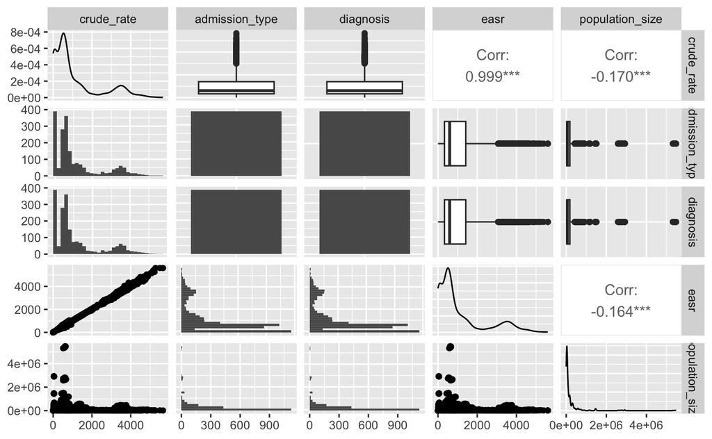

```r
ggpairs(set_2)
```

```r
# variables of interest: hbr, age_group and sex (but not so obvious from the ggpairs plot)?
# definitely interaction between those!
```